# Lab7

Luis Mario Trevisi

2020-10-09

# Task 1

```r
getwd()
```

```
## [1] "C:/Users/Luis Mario Trevisi/OneDrive - University of Oklahoma/OU/Applied Statistical Methods/Math4753/MATH4753ouTrev0002/Laboratories/Lab 7"
```

# Task 2

## Making the four plots

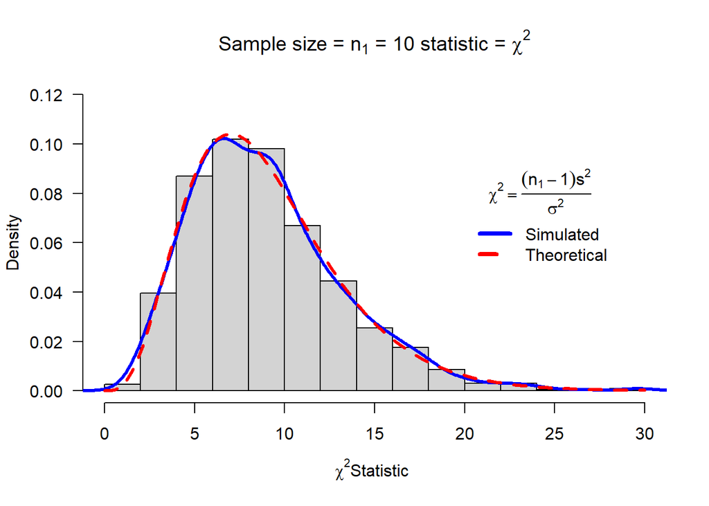

```r
library(MATH4753ouTrev0002)
mychisim(n1=10,iter=1000,mean1=10,sigma1=4,ymax=0.12,y=0.08)
```

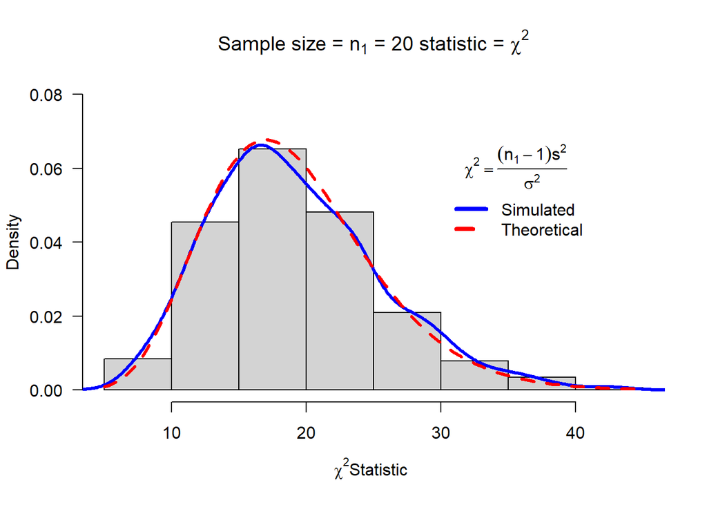

```r
mychisim(n1=20,iter=1000,mean1=10,sigma1=4,ymax=0.08,y=0.06,x=30)
```

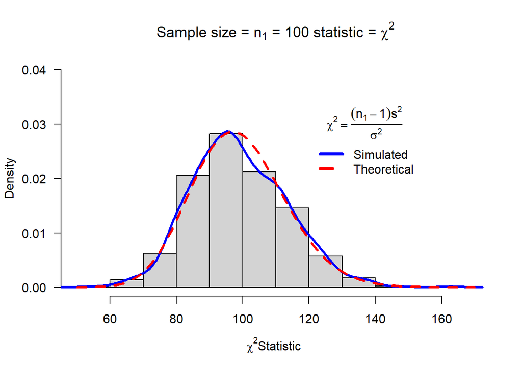

```r
mychisim(n1=100,iter=1000,mean1=10,sigma1=4,ymax=0.04,y=0.03,x=120)
```

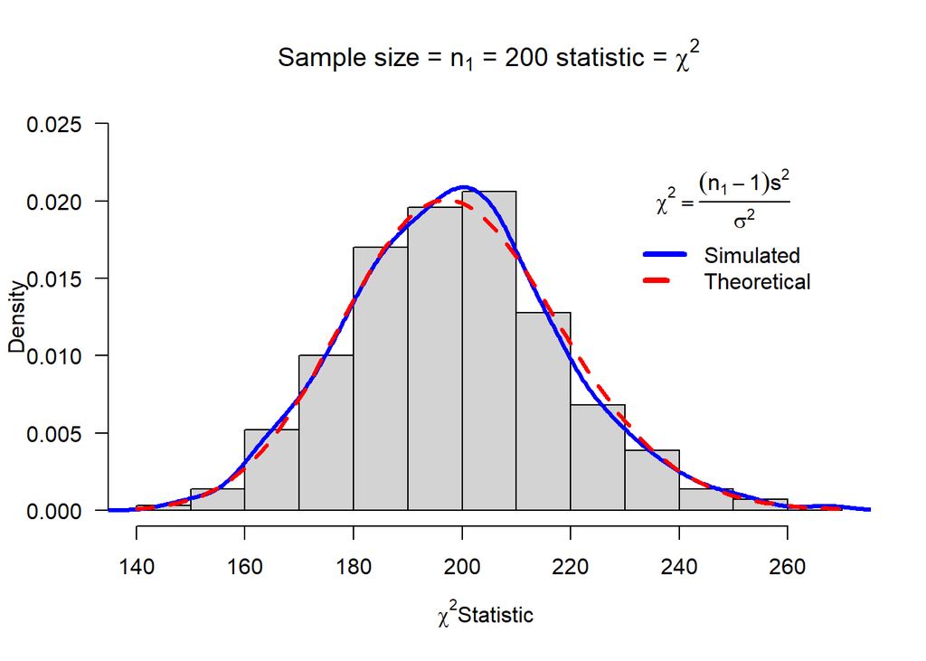

```r
mychisim(n1=200,iter=1000,mean1=10,sigma1=4,ymax=0.025,y=0.02,x=230)
```

## Place output in object and making histogram

```r
chisq<-mychisim(n1=10,iter=1500,mean1=20,sigma1=10)
```

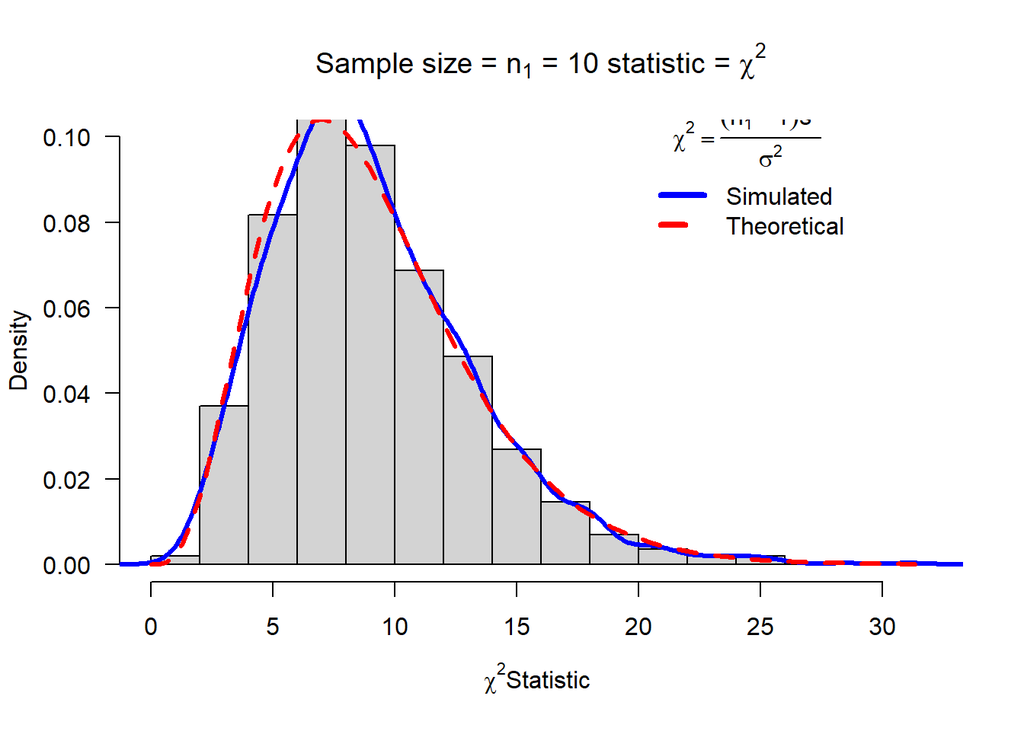

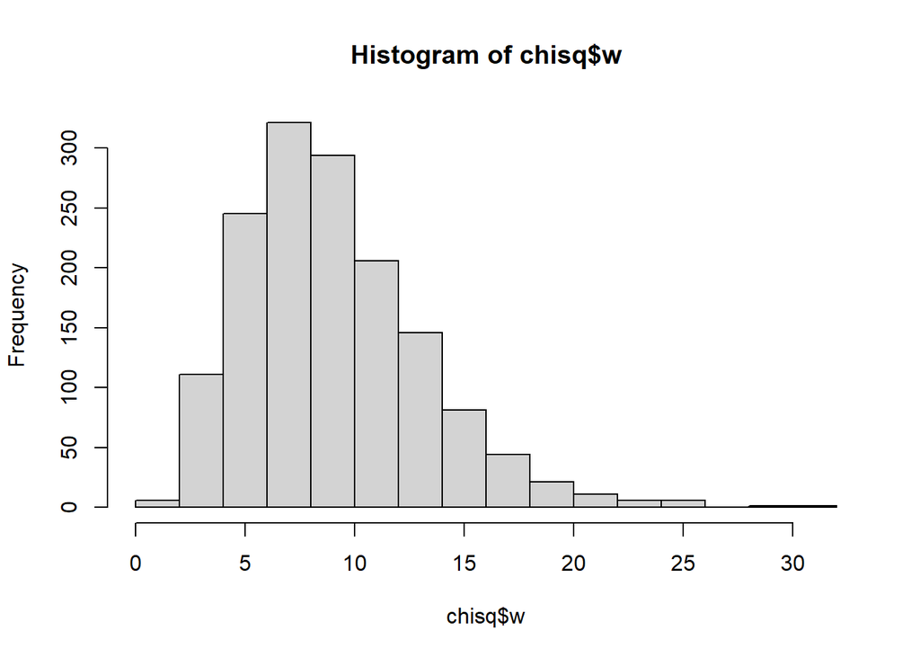

```r
hist(chisq$w)
```

# Task 3

## Make the plots

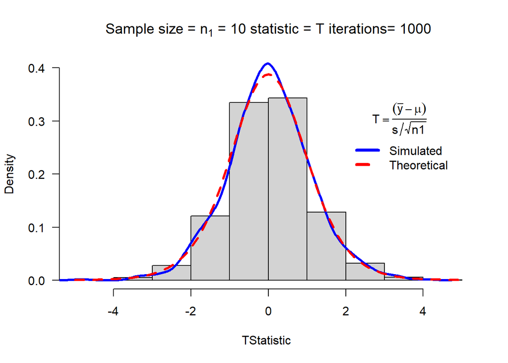

```r
library(MATH4753ouTrev0002)
myTsim(n1=10,iter=1000,mean1=10,sigma1=4,ymax=0.4,y=0.3,x=2)
```

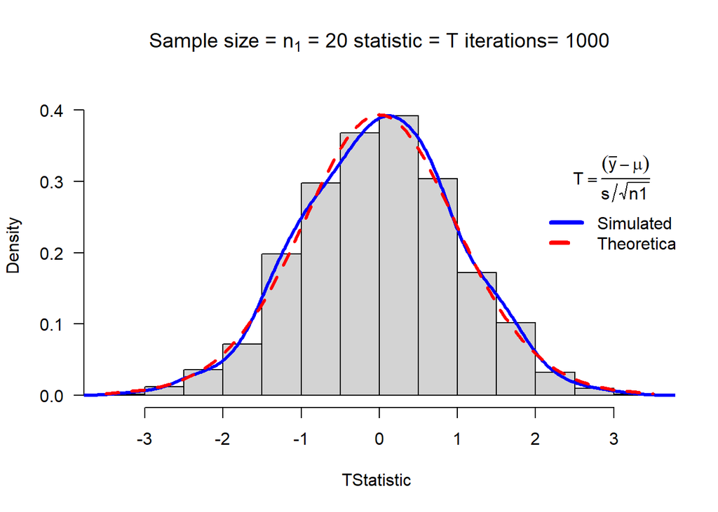

```r
myTsim(n1=20,iter=1000,mean1=10,sigma1=4,ymax=0.42,y=0.3,x=2)
```

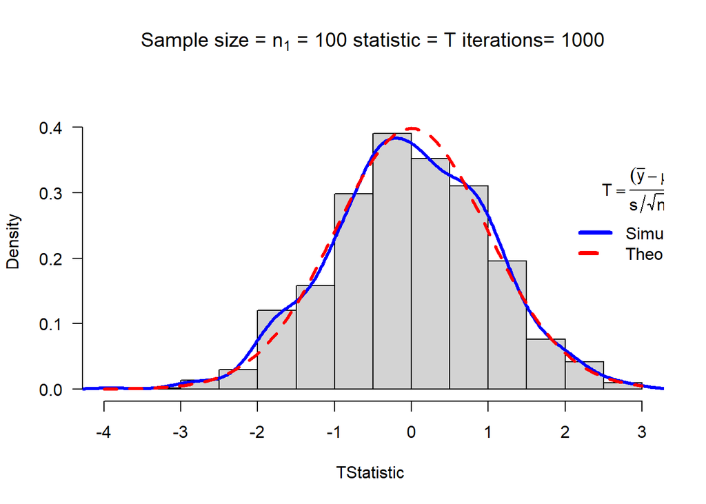

```r
myTsim(n1=100,iter=1000,mean1=10,sigma1=4,ymax=0.45,y=0.3,x=2)
```

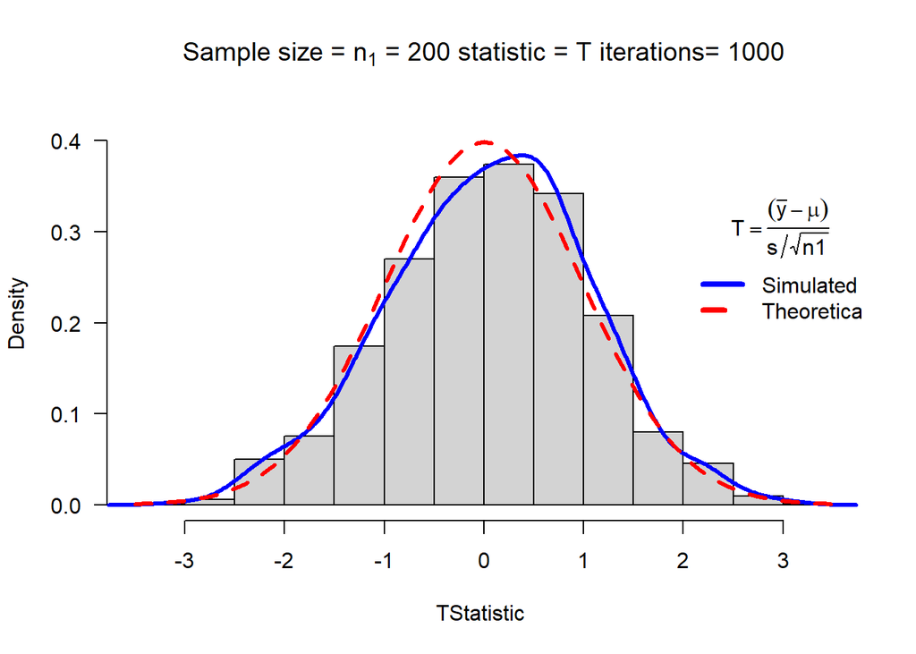

```r
myTsim(n1=200,iter=1000,mean1=10,sigma1=4,ymax=0.42,y=0.3,x=2)
```

## Place output in object and making histogram

```r
T<-myTsim(n1=10,iter=1500,mean1=20,sigma1=10)
```

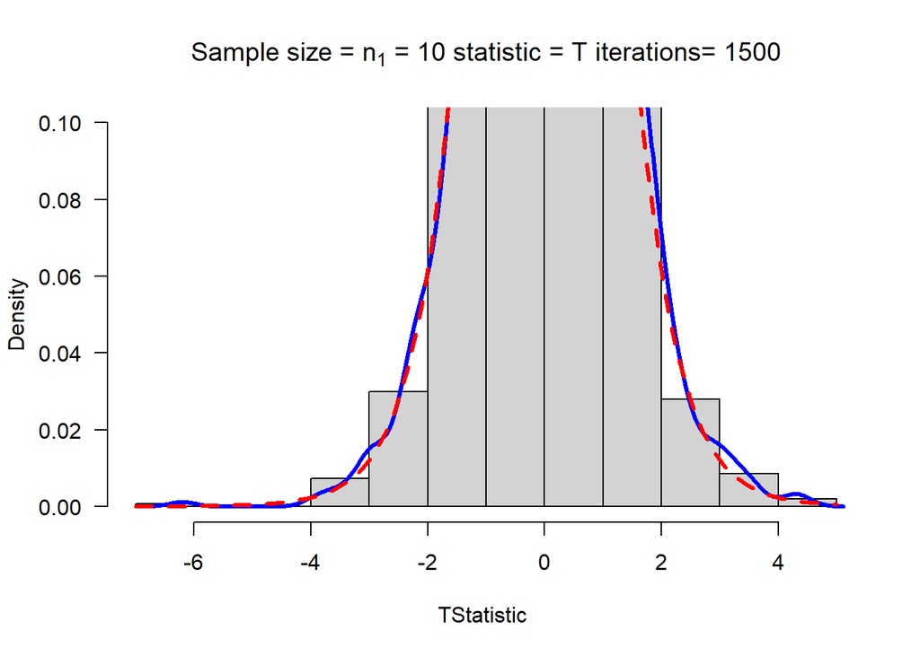

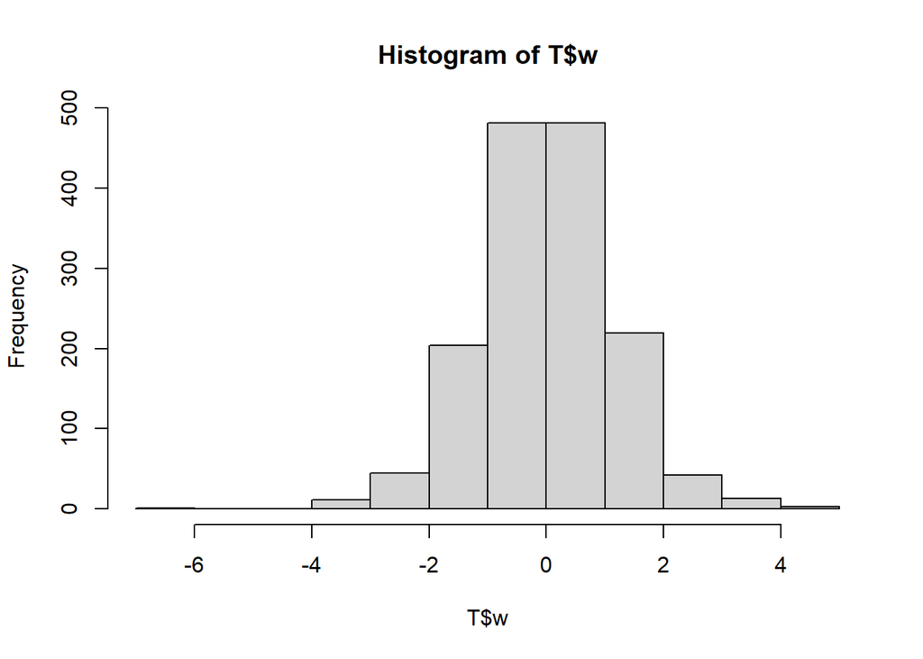

```r
hist(T$w)
```

# Task 4

## Make the plots

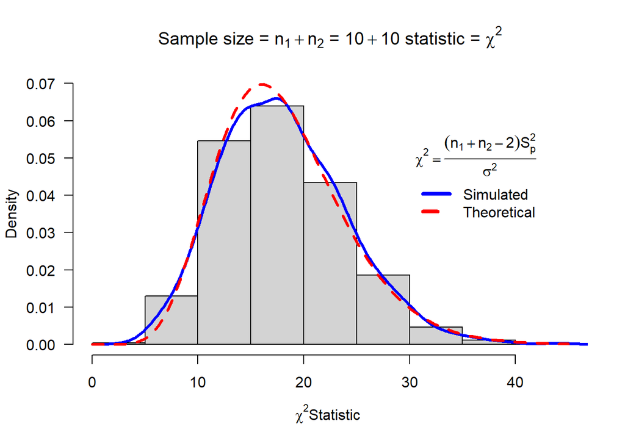

```r
library(MATH4753ouTrev0002)
mychisim2(n1=10,n2=10,mean1=5,mean2=10,sigma1=4,sigma2=4,iter=1000,ymax=0.07,y=0.05,x=30)
```

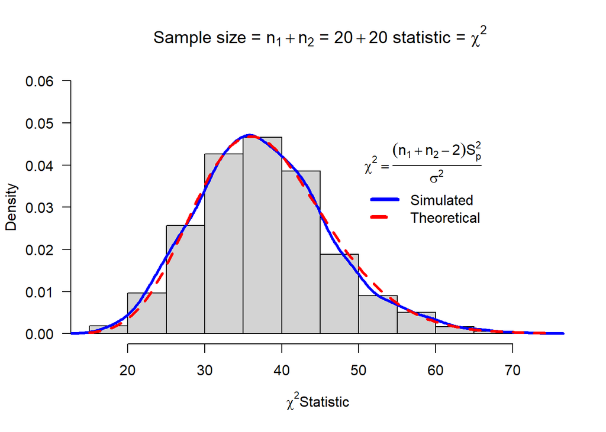

```r
mychisim2(n1=20,n2=20,mean1=3,mean2=5,sigma1=10,sigma2=10,iter=1000,ymax=0.06,y=0.04,x=50)
```

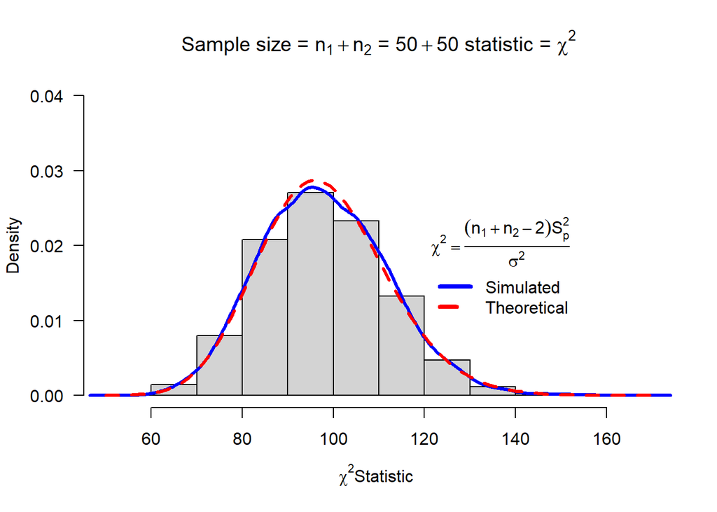

```r
mychisim2(n1=50,n2=50,mean1=5,mean2=10,sigma1=4,sigma2=4,iter=10000,ymax=0.04,y=0.02,x=120)
```

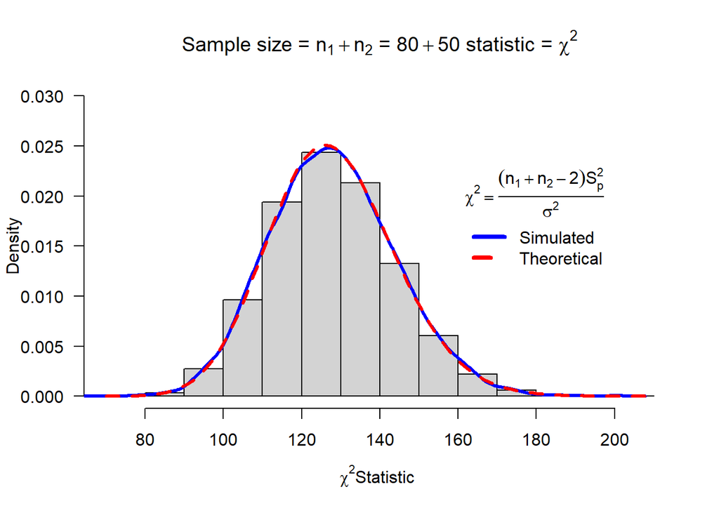

```r
mychisim2(n1=80,n2=50,mean1=3,mean2=5,sigma1=10,sigma2=10,iter=10000,ymax=0.03,y=0.02,x=160)
```

## Place output in object and making histogram

```r
chisq2<-mychisim2(iter=10000)
```

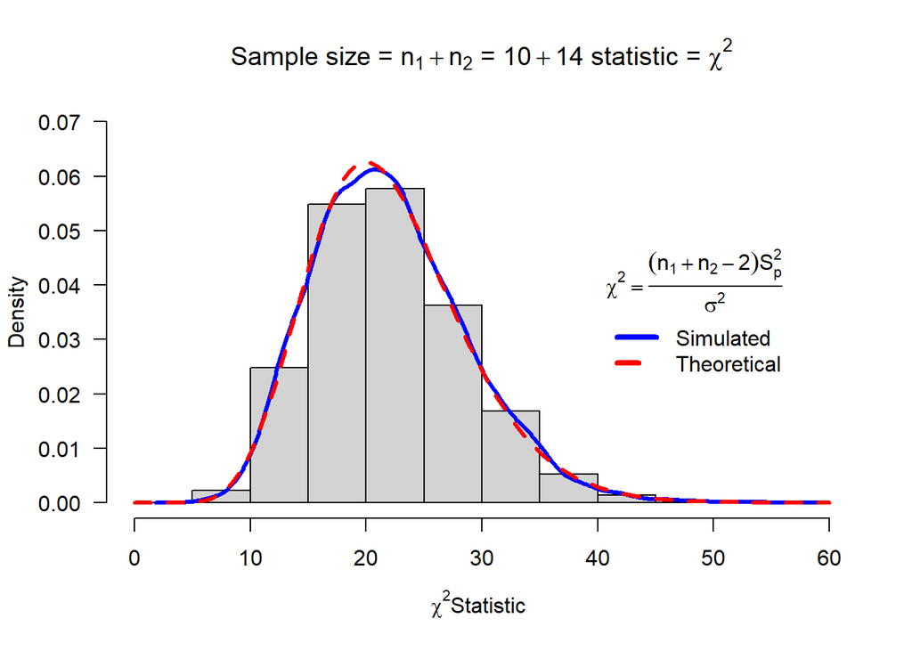

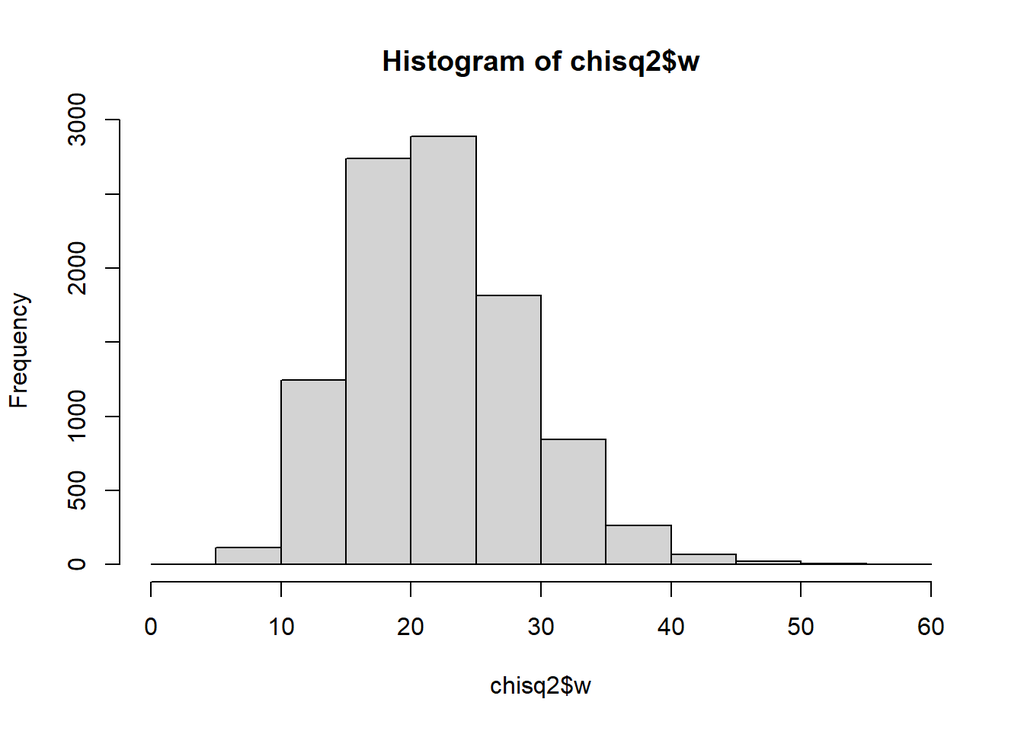

```r
hist(chisq2$w)
```

# Task 5

## place the legend where you click with the mouse

we do this by changing x,y by the function locator(1), nevertheless this cannot be done on the markdown as it would need user interaction. this code would only work on an r file. Thus, it is not shown above but explain.

## write down the student’s T statistic

$T = \frac{(\bar{Y_1}-\bar{Y_2})-(\mu_1-\mu_2)}{S_p\sqrt{\frac{1}{n_1}+\frac{1}{n_2}}}$

$S_p^2 = \frac{(n_1-1)*S_1^2+(n_2-1)*S_2^2}{n_1+n_2-2}$

where:

$\bar{Y_1}$ is the mean of the sample 1

$\bar{Y_2}$ is the mean of the sample 2

$\mu_1$ is the mean of the population 1

$\mu_2$ is the mean of the population 2

$S_p$ pooled sample standard deviation

$n_1$ is the sample size of 1

$n_2$ is the sample size of 2

$S_1$ sample standard deviation 1

$S_2$ sample standard deviation 2

## Make Plots

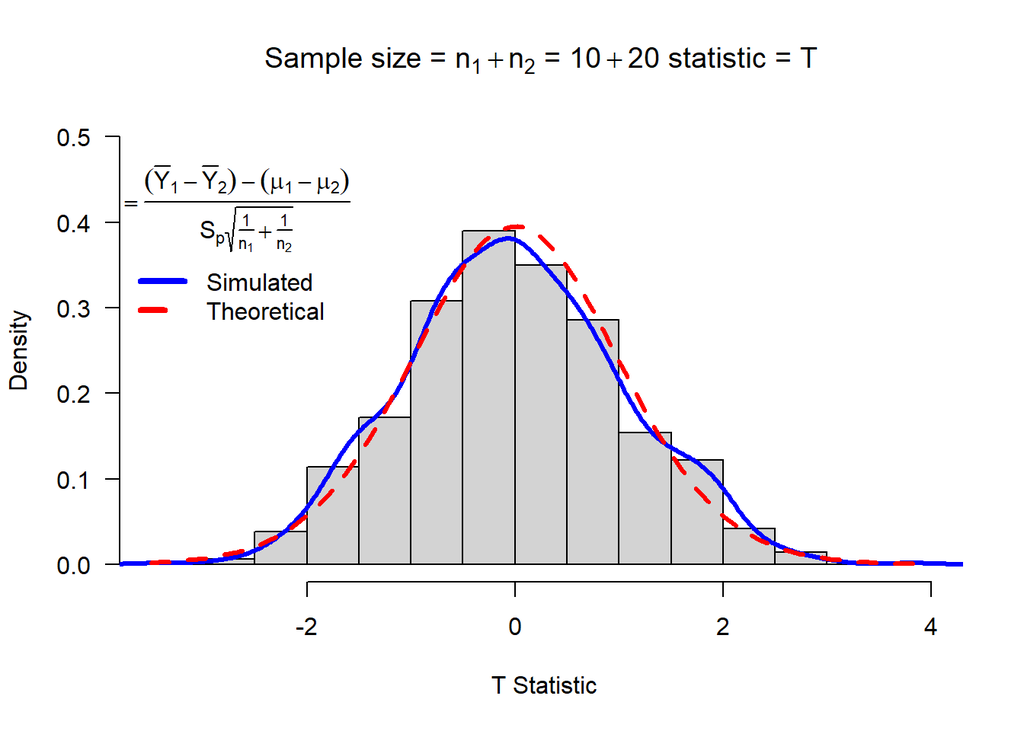

```r
library(MATH4753ouTrev0002)
myTsim2(n1=10,n2=20,mean1=5,mean2=10,sigma1=4,sigma2=4, iter=1000,ymax= 0.5,y=0.4,x= -4 )
```

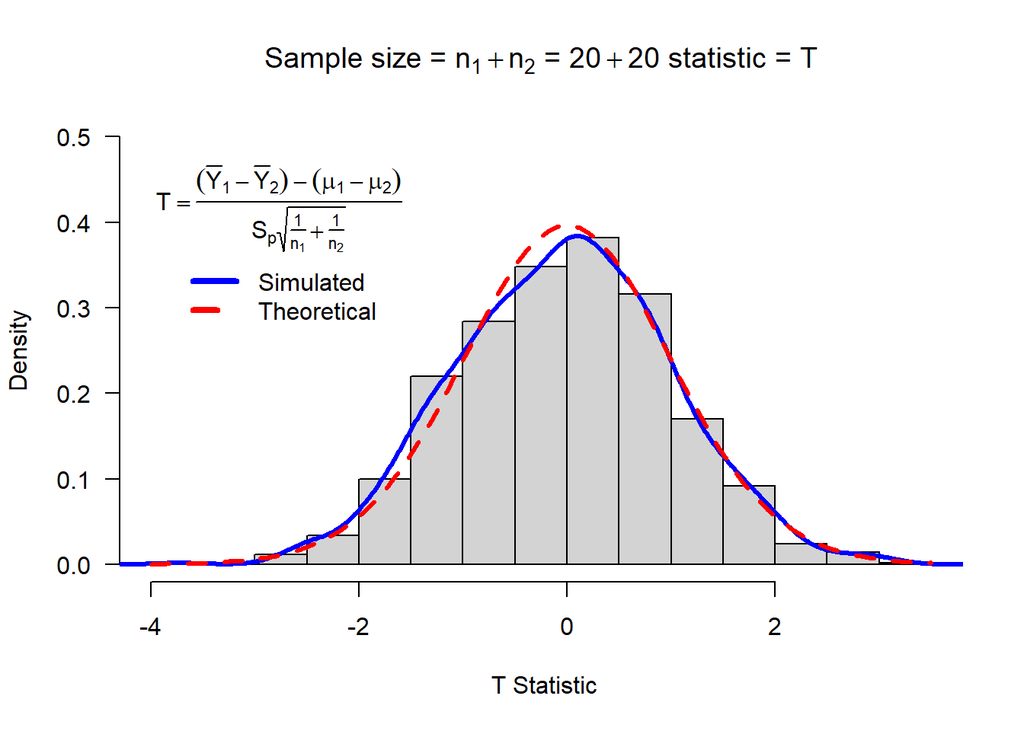

```r
myTsim2(n1=20,n2=20,mean1=3,mean2=5,sigma1=10,sigma2=10, iter=1000,ymax= 0.5,y=0.4,x= -4 )
```

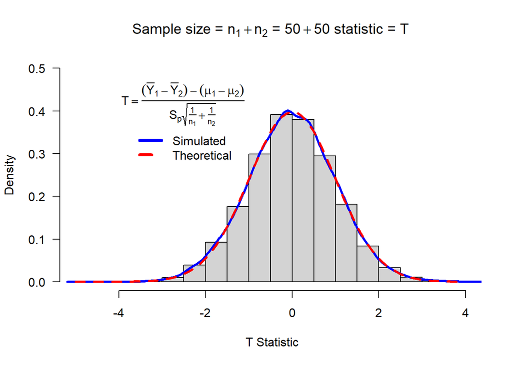

```r
myTsim2(n1=50,n2=50,mean1=5,mean2=10,sigma1=4,sigma2=4, iter=10000,ymax= 0.5,y=0.4,x= -4 )
```

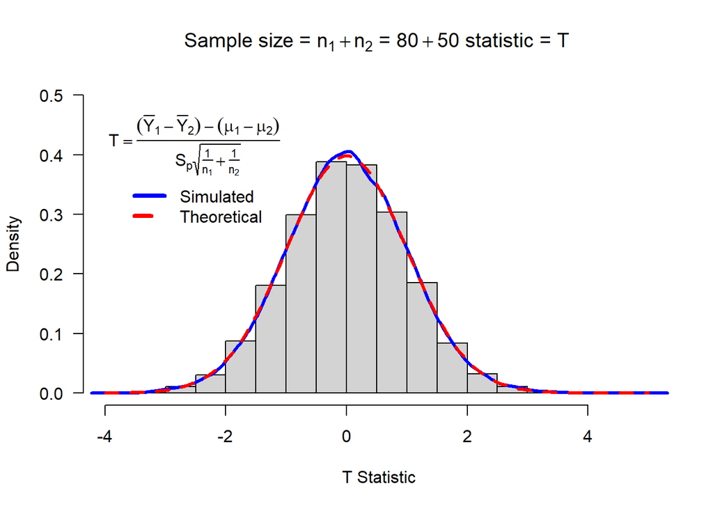

```r
myTsim2(n1=80,n2=50,mean1=3,mean2=5,sigma1=10,sigma2=10, iter=10000,ymax= 0.5,y=0.4,x= -4 )
```

## Place output in object and making histogram

```r
T2<-myTsim2(iter=10000)
```

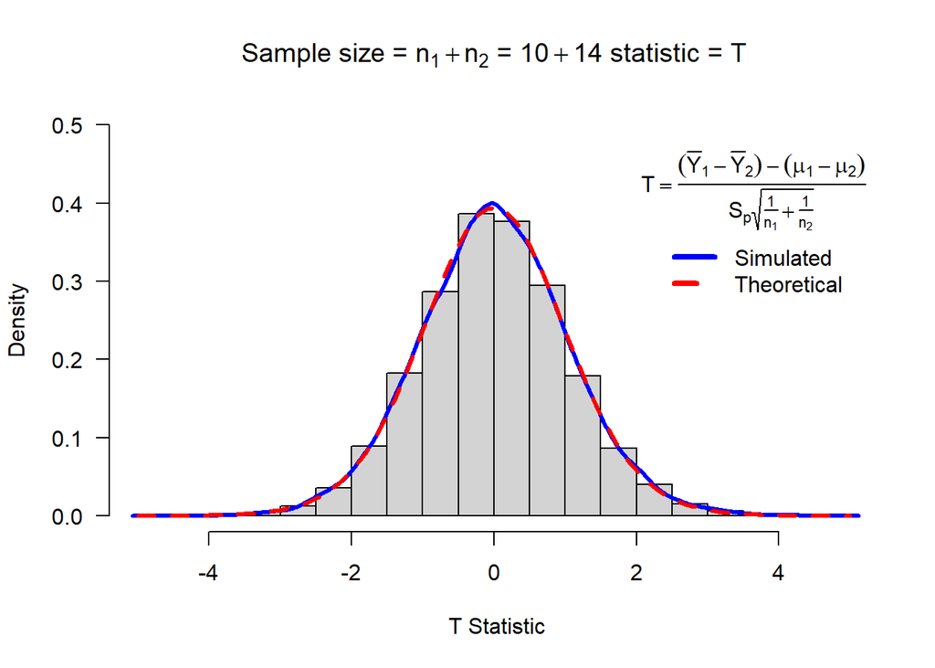

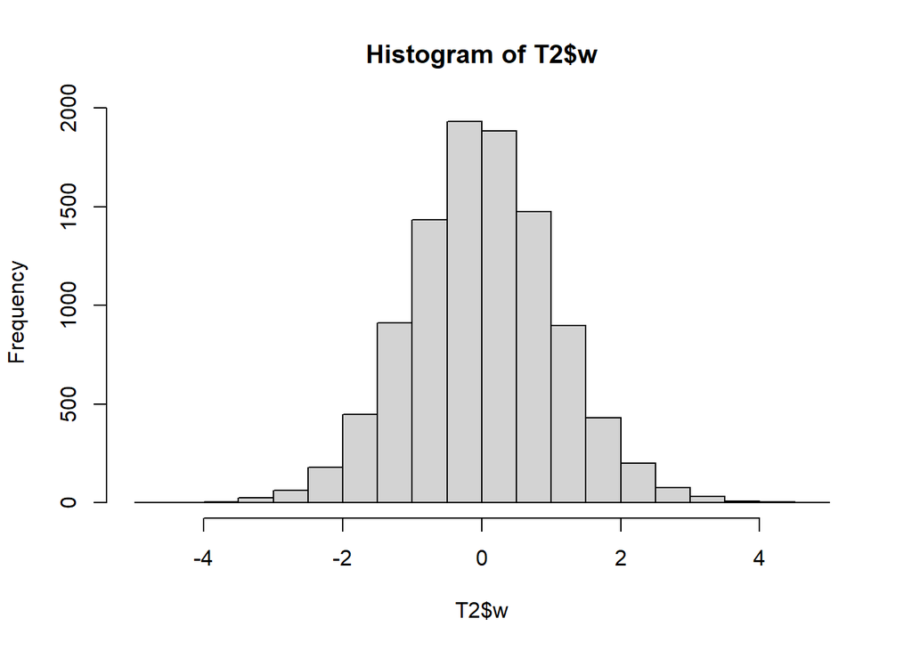

```r
hist(T2$w)
```

# Task 6

## What assumptions are made?

it is assumed that chi-squared random variables are independent

## Make four plots with different parameters

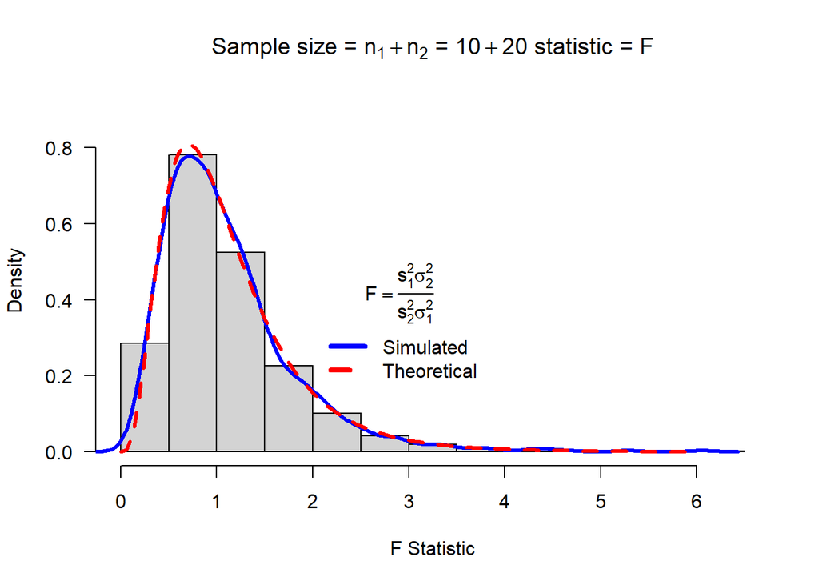

```r
library(MATH4753ouTrev0002)
myFsim2(n1=10,n2=20,mean1=5,mean2=10,sigma1=4,sigma2=4, iter=1000,ymax= 0.9,y=0.4,x= 2 )
```

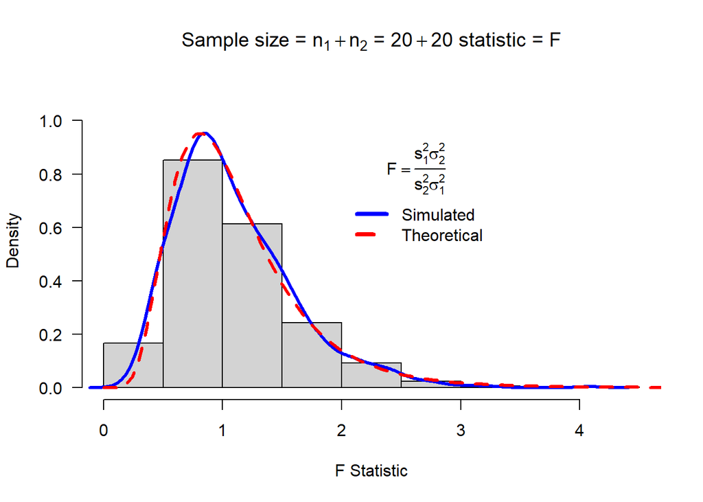

```r
myFsim2(n1=20,n2=20,mean1=3,mean2=5,sigma1=10,sigma2=10, iter=1000,ymax= 1.1,y=0.8,x= 2 )
```

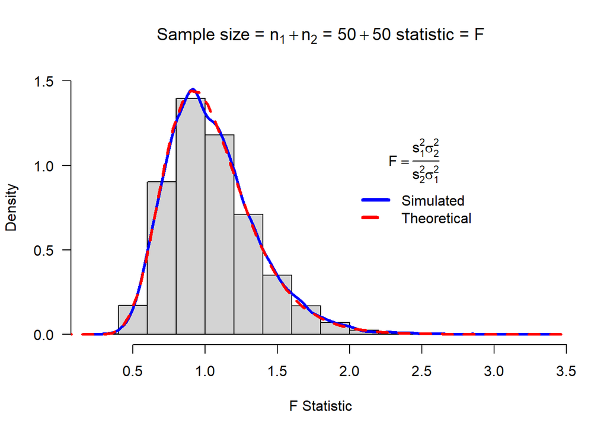

```r
myFsim2(n1=50,n2=50,mean1=5,mean2=10,sigma1=4,sigma2=4, iter=10000,ymax= 1.5,y=1,x= 2 )
```

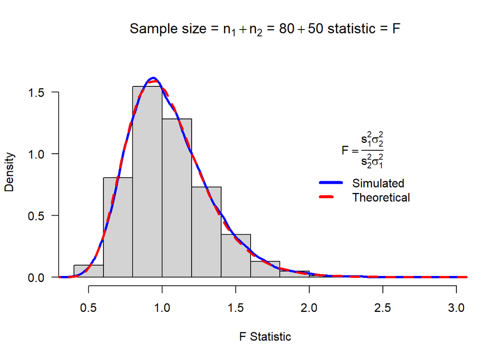

```r
myFsim2(n1=80,n2=50,mean1=3,mean2=5,sigma1=10,sigma2=10, iter=10000,ymax= 1.7,y=1,x= 2 )
```

## Place output in object and making histogram

```r
F2<-myTsim2()
```

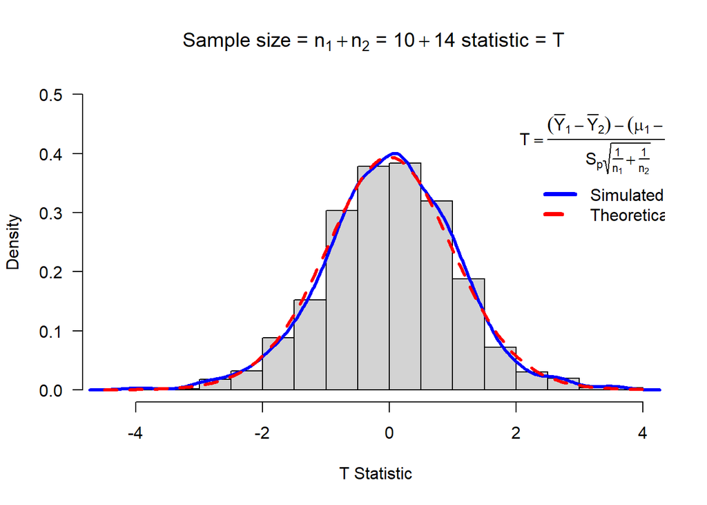

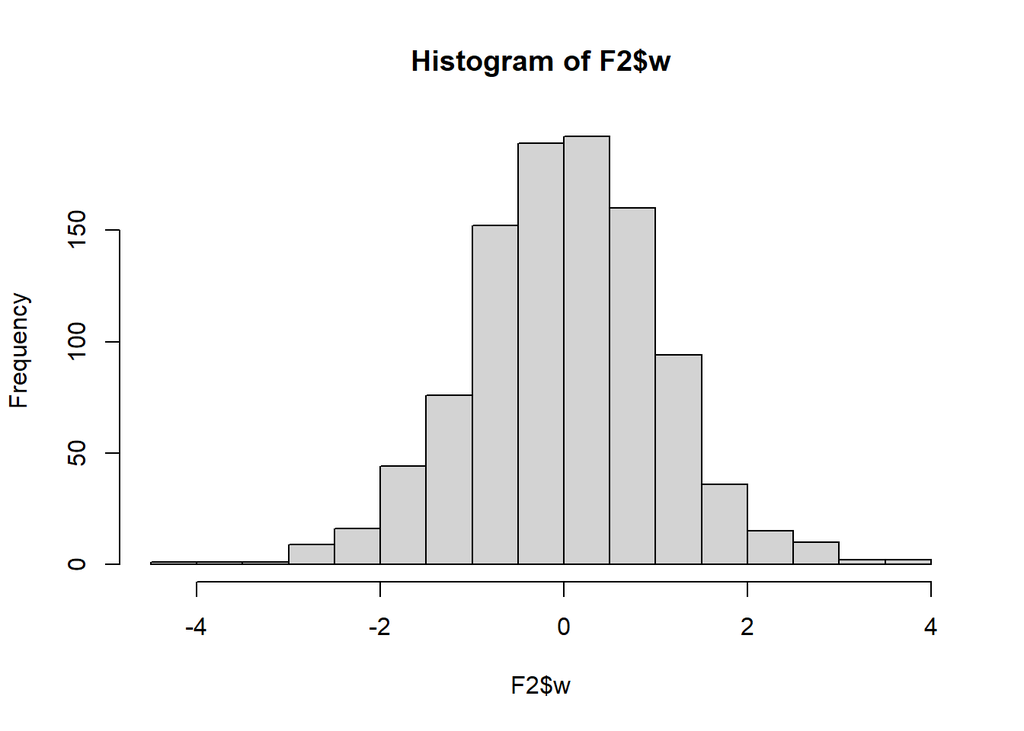

```r
hist(F2$w)
```

# Task 7

```r
library(MATH4753ouTrev0002)
data("fire")
knitr::kable(head(fire))
```

| DISTANCE | DAMAGE |
| --- | --- |
| 3.4 | 26.2 |
| 1.8 | 17.8 |
| 4.6 | 31.3 |
| 2.3 | 23.1 |
| 3.1 | 27.5 |
| 5.5 | 36.0 |